# 第5回 授業資料

Higashiguchi Rinhi

2024-11-07

# 1 質問・コメント

今回の授業では詳しく触れていませんでしたが、ベイズ統計が心理統計学にどう応用されているのか例が知りたいです。

→(間に合わなかったので)来週やります

質問紙を使った心理学研究の「予備調査の分析、質問紙の編集（修正）、本調査の分析」という流れの中で、「こういうときにこの分析を使う」というような、典型的なパターンのようなものがもしあれば知りたいと思いました。

この分析の目的が何なのかが分からなくなってしまい、Rでもまず何をすればいいのかというところで止まってしまうことが多いです。

→(まとめとしてよいと思うので)来週やります

# 2 第4回の復習・補足

第3回、第4回でPCA, EFAの数式的表現を紹介しましたが、相関行列とモデル推定の話を少しかみ砕いて説明できればと思います。

[分寺先生の資料](https://www2.kobe-u.ac.jp/~bunji/files/lecture/MVA/mva-06-factor-analysis.pdf)の第6.3節を参考にしました。

回答者$i$人、項目$j$に対しての因子分析モデルは以下のようにあらすことができる:

$$\textbf x_i = \textbf c +\textbf A \textbf f_i + \textbf e_i$$
観測変数の相関行列$\Sigma$を考える。 相関行列とは異なる変数の相関係数が行と列に並んでいるものと考えてください。

例えば4項目ある質問紙の分散共分散行列(**相関行列**)は以下のようになります。なお、各項目の回答は標準化されていることを考えると、変数間の共分散と相関係数は一致します。

$$\Sigma=
\begin{bmatrix}
\sigma^2_{x_1} & \sigma_{x_1,x_2} & \sigma_{x_1,x_3} &
\sigma_{x_1,x_4} \\
\sigma_{x_2,x_1} & \sigma^2_{x_2} & \sigma_{x_2,x_3} &
\sigma_{x_2,x_4} \\
\sigma_{x_3,x_1} & \sigma_{x_3,x_2} & \sigma^2_{x_3} &
\sigma_{x_3,x_4} \\
\sigma_{x_4,x_1} & \sigma_{x_4,x_2} & \sigma_{x_4,x_3} &
\sigma^2_{x_4} \\
\end{bmatrix}$$

ある項目$\textbf x_i$のモデル式は以下のように記述できる

$$\textbf x_i =a_i \textbf f + \textbf
e_i .$$

$\textbf x_i$と$\textbf x_j$の間の共分散$\sigma^2_{ij}$を考える。心理統計学の基礎付録A.4にも同様の内容はあります。

$$\sigma_{\textbf x_i, \textbf x_j} = \sigma_{(a_i \textbf f + \textbf
e_i ),(a_j \textbf f + \textbf e_j)} \\
=\sigma_{(a_i \textbf f), (a_j \textbf f) } +\sigma_{(a_i \textbf f), (
\textbf e_j) } +
\sigma_{(a_j \textbf f), ( \textbf e_i) } + \sigma_{( \textbf e_i), (
\textbf e_j) } \\
=a_ia_j\sigma_\textbf f^2 + \sigma_{(a_i \textbf f), ( \textbf e_j) } +
\sigma_{(a_j \textbf f), ( \textbf e_i) } +\sigma_{( \textbf e_i), (
\textbf e_j) }$$

ここである項目の共通因子成分と別の因子の独自因子成分は共分散0とみなすことができるため

$$\sigma_{(a_i \textbf f), ( \textbf e_j) } =
\sigma_{(a_j \textbf f), ( \textbf e_i) } = 0$$

となる。

$$\sigma_{\textbf x_i, \textbf x_j} =a_ia_j\sigma_\textbf f^2 +\sigma_{(
\textbf e_i), ( \textbf e_j) }$$

因子分析のモデルは$\textbf f$のスケールが変わることで他のパラメータ($aやe$)の解が一意に定まらないので、因子の分散$\sigma_\textbf f^2=1$という制約がおかれている。

第4回のスライドではこのような

$$\textbf f_i \sim iif. MultiNormal(0_m,I_m)$$

確率分布に従うと紹介した。

以上をまとめると

$$\sigma_{\textbf x_i, \textbf x_j} = r_{\textbf x_i, \textbf x_j} =
a_ia_j+\sigma_{( \textbf e_i), ( \textbf e_j) }$$

同様にして項目$\textbf x_i$の分散は

$$\sigma_{\textbf x_i}^2 = a_i^2+\sigma^2_{\textbf e_i}$$

のようになります。因子分析では項目$\textbf x_i$の分散$\sigma_{\textbf x_i}^2=1$のうち共通因子で説明可能な分散の割合を**共通性**(communality)、独自因子で説明可能な分散の割合を**独自性**(uniqueness)と呼びます。

観測変数の相関行列$\Sigma$は以下のように因子分析のパラメータの関数に変換することができます。

$$\Sigma=
\begin{bmatrix}
\sigma^2_{x_1} & \sigma_{x_1,x_2} & \sigma_{x_1,x_3} &
\sigma_{x_1,x_4} \\
\sigma_{x_2,x_1} & \sigma^2_{x_2} & \sigma_{x_2,x_3} &
\sigma_{x_2,x_4} \\
\sigma_{x_3,x_1} & \sigma_{x_3,x_2} & \sigma^2_{x_3} &
\sigma_{x_3,x_4} \\
\sigma_{x_4,x_1} & \sigma_{x_4,x_2} & \sigma_{x_4,x_3} &
\sigma^2_{x_4} \\
\end{bmatrix} \\
=\begin{bmatrix}
a_1^2 + \sigma^2_{e_1} & a_1 a_2 & a_1 a_3 & a_1 a_4 \\
a_2 a_1 & a_2^2 + \sigma^2_{e_2} & a_2 a_3 & a_2 a_4 \\
a_3 a_1 & a_3 a_2 & a_3^2 + \sigma^2_{e_3} & a_3 a_4 \\
a_4 a_1 & a_4 a_2 & a_4 a_3 & a_4^2 + \sigma^2_{e_4} \\
\end{bmatrix} \\
=\begin{bmatrix}
a_1^2 & a_1 a_2 & a_1 a_3 & a_1 a_4 \\
a_2 a_1 & a_2^2 & a_2 a_3 & a_2 a_4 \\
a_3 a_1 & a_3 a_2 & a_3^2 & a_3 a_4 \\
a_4 a_1 & a_4 a_2 & a_4 a_3 & a_4^2 \\
\end{bmatrix}
+
\begin{bmatrix}
\sigma^2_{e_1} & 0 & 0 & 0 \\
0 & \sigma^2_{e_2} & 0 & 0 \\
0 & 0 & \sigma^2_{e_3} & 0 \\
0 & 0 & 0 & \sigma^2_{e_4} \\
\end{bmatrix} \\
=\begin{bmatrix}
a_1 \\
a_2 \\
a_3 \\
a_4 \\
\end{bmatrix}
\begin{bmatrix}
a_1 & a_2 & a_3 & a_4 \\
\end{bmatrix}
+ \Psi \\
= \mathbf a \mathbf a^\top + \Psi$$

実際の計算のイメージとしては次のような感じです。

1. 観測変数の相関行列$\Sigma$の非対角成分について$\mathbf a \mathbf a^\top$がなるべく近い値になるような因子負荷ベクトル$\textbf a$を求める
2. 対角成分の値が 1 になるように$\Psi$で調整する

こうして得られた因子負荷および誤差分散を固定した上で$x$ とのズレが最も小さくなるように因子得点$f$の値が計算されます。

これを多因子に拡張すると相関行列は以下のようになります。
$$\Sigma =\textbf A\textbf A^⊤ +𝚿$$

# 3 様々な相関係数

変数の性質に応じて、用いる尺度は4つに分けることができます。 可能な演算を見るとこれらは包含関係にあることがわかります。

1. 名義尺度(Nominal): 質的データ、可能な演算: $=, \neq$ 具体例:血液型、都道府県など
2. 順序尺度(Ordered): 質的データ、可能な演算: $=, \neq, <, >$ 具体例: 順位など
3. 間隔尺度(Interval): 量的データ、可能な演算: $=, \neq, <, >, -$ 具体例: 日付、温度、成績など
4. 比例尺度(Ratio): 量的データ、可能な演算: $=, \neq, <, >, -, /$ 具体例: 値段、身長など

心理尺度でデータを測定した場合、5件法や6件法によるリッカート法を使うことが多いと思います。

小杉(2008, 2019)より

```
統計学者に言わせると，連続変数と見なしていいのは七件法からで (吉野・千野・山崎,2007)，
それ以下のものはせいぜい順序尺度レベルであるからだ。順序尺度レベルということは，加減乗除の対象にならないってことで，平均をとるのは勿論，相関係数を求めて因子分析するなんて，もってのほかということになる。
```

といった感じで、通常のリッカート尺度でとったデータでそのまま因子分析を行うことは推奨されない。

[清水先生のブログ(2012)](https://norimune.net/673)より

```
このようなリッカート法を使ってデータを収集する場合、得られた値を「間隔尺度」として扱って分析することがほとんどです。これはもちろん、間隔尺度のほうが扱える分析法が圧倒的に多いので、便利だからです。
しかし、心理学者の中でも、リッカート尺度は本来「順序尺度」なので、間隔尺度として扱うことに限界を感じている研究者も多いです。その理由としては、値に与えられているラベル（まったく当てはまらない、など）間の間隔がすべて等しい、という仮定が怪しいことと例えば5件法なら、1より小さい値、あるいは5より大きい値を得られないので、測定上の制限がある
```

と書かれておられ大きな問題点として順序尺度を間隔尺度として扱っており、順序尺度では**加減乗除の対象にならない**のでよくない。

間隔尺度はどうして連続変数としてみなしてよいのはどうしてかという細かい話は[専門的な参考書](https://www.kinokuniya.co.jp/f/dsg-01-9784563058951)をご参照ください。

対処法として以下の3点があげられているが、本日は2.を詳しく見ていく。

```
統計学的には，早くから正しい方法が示されている。例えば狩野・三浦 (2002) によると，順序尺度を分析するには
1. 連続とみなす
2. 多分相関係数（polychoric correlation coefficient），多分系列相関係数 (polyserial correlation coefficient)を使う
3. 多項分布に基づく方法をとる
の三択になるとしている。
```

用語の紹介です。

- Polychoric correlation coefficient: 順序尺度と順序尺度の相関係数。本稿ではpolychoric相関係数と呼ぶ。
- Polyserial correlatiion coefficient: 順序尺度と間隔尺度の相関係数。例えば各項目(順序尺度)とテストの合計点(間隔尺度; それなりの項目数があれば合計点は連続的だと考える)を用いる項目反応理論のGraded Response Modelで使用する。本稿ではpolyserial相関係数と呼ぶ。

## 3.1 Polychoric相関係数

Polychoric相関係数を考える場合は $- $の 連続な潜在変数が背後にあると考え、それらがそれぞれ**正規分布**に従っていると仮定する。

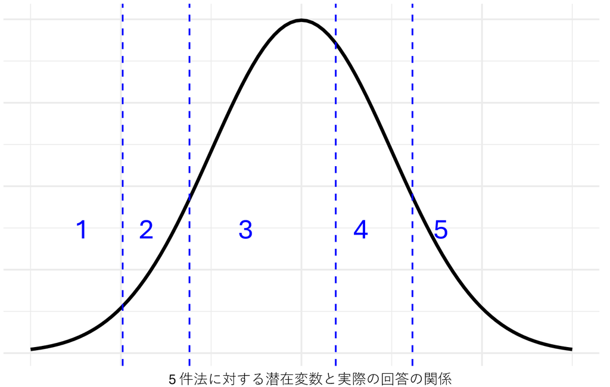

その連続量を5件法の尺度で測定した場合「4. 部分的にそうである」、「5. そうである」、という形で現れる上、 ある量(=閾値)を超えると4.から5.に代わると考えます。ですが、このときそれぞれの閾値はどこにあるのかわからない。

順序尺度である変数のpolychoric相関係数はその背後の連続変数間のピアソンの相関係数の推定値であるよ、ということである。

ここでは簡単にその計算方法を追ってみる。

例として5件法のリッカート尺度を用いて測定された変数$x$と$y$を考える。

```r
library(ggplot2)
library(dplyr)
library(psych)
library(polycor)
library(gridExtra)
```

```r
set.seed(4747)
n <- 1000  # sample size

# Generate two continuous latent variables with a correlation
latent_var1 <- rnorm(n)
latent_var2 <- 0.7 * latent_var1 + sqrt(1 - 0.7^2) * rnorm(n)  # Correlated with latent_var1
ord_var1 <- cut(latent_var1, breaks = quantile(latent_var1, probs = seq(0, 1, by = 0.2)), labels = 1:5, include.lowest = TRUE)
ord_var2 <- cut(latent_var2, breaks = quantile(latent_var2, probs = seq(0, 1, by = 0.2)), labels = 1:5, include.lowest = TRUE) #0%, 20%, 40%, 60%, 80%, and 100% quantiles


data <- data.frame(latent_var1, latent_var2, ord_var1, ord_var2)
```

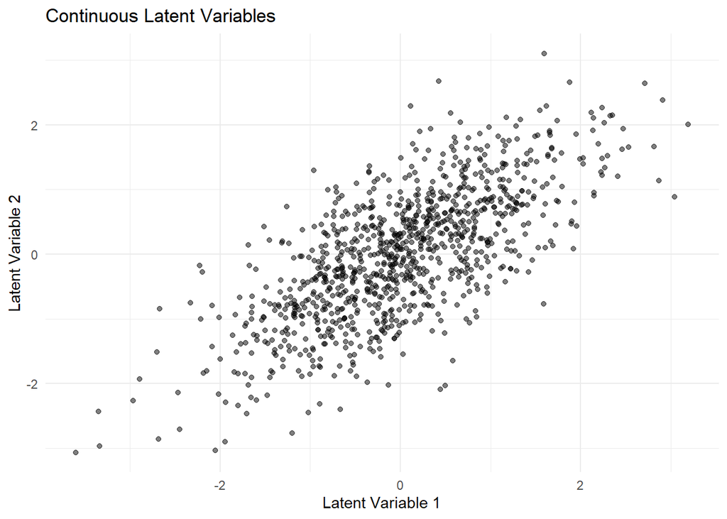

```r
p1 <- ggplot(data, aes(x = latent_var1, y = latent_var2)) +
  geom_point(alpha = 0.5) +
  labs(title = "Continuous Latent Variables", x = "Latent Variable 1", y = "Latent Variable 2") +
  theme_minimal()

print(p1)
```

順序尺度に変換したデータのクロス集計表及びその3-D棒グラフは以下のようになる。

```r
freq_table <- table(ord_var1, ord_var2)
print(freq_table)
```

```
        ord_var2
ord_var1   1   2   3   4   5
       1 109  58  24   8   1
       2  50  62  39  36  13
       3  30  43  63  44  20
       4  10  28  42  69  51
       5   1   9  32  43 115
```

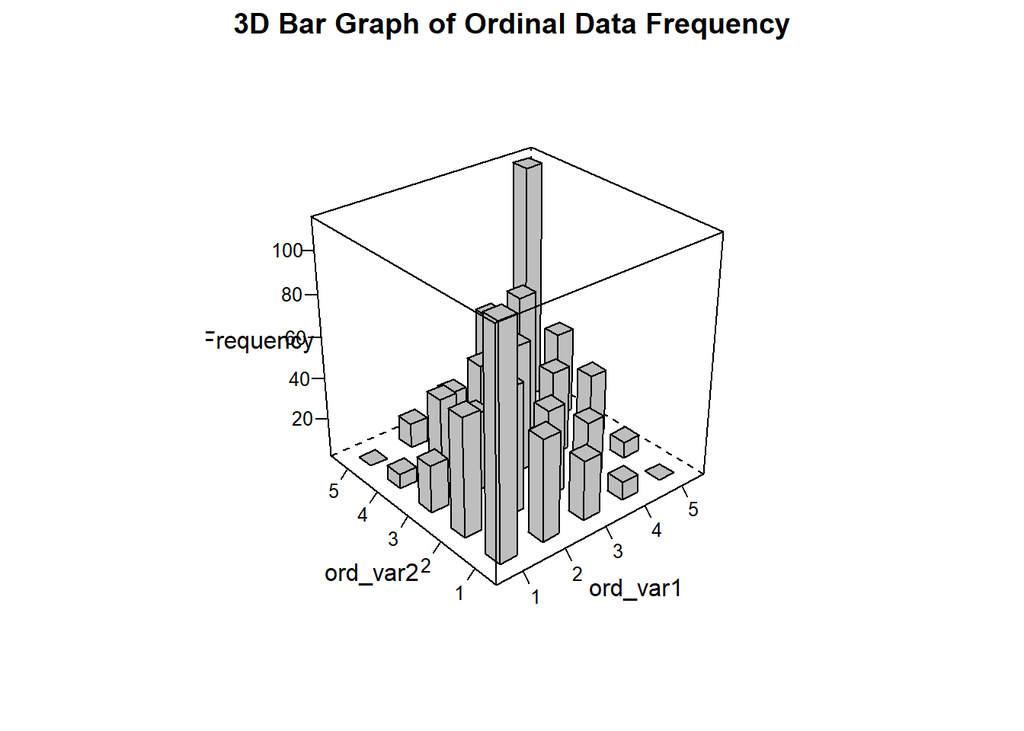

```r
df <- as.data.frame(freq_table)
colnames(df) <- c("ord_var1", "ord_var2", "Frequency")

cloud(Frequency ~ ord_var1 * ord_var2, data = df,
      panel.3d.cloud=panel.3dbars, col.facet='grey',
      xlab = "ord_var1", ylab = "ord_var2", zlab = "Frequency",
      xbase=0.4, ybase=0.4, scales=list(arrows=FALSE, col=1),
      par.settings = list(axis.line = list(col = "transparent")),
      main = "3D Bar Graph of Ordinal Data Frequency")
```

イメージとしては上記のクロス集計表の棒グラフを二変量正規分布にした場合、 一番妥当なプロット(つまり$\rho$)はどれかを考えることである。

実際、polychoric相関係数を推定するとき推定すべきパラメータは，相関係数$\rho$だけではなく、変数$x$に含まれる閾値と変数$y$に含まれる閾値を推定することになる。 この例では各変数の20%, 40%…で分けて5分割しましたが、当然閾値を変えるとクロス集計表も変わってくる。

ここで皆様おなじみの「最尤法」の考え方を用いて、手元のデータが得られるのはどのようなパラメータのといが一番高いかを考えます。

具体的には2つの方法があるそうで、1つめは全てのパラメータを同時に推定する方法(偏微分方程式をいっぱい解くので面倒)、もう一つは閾値を(周辺度数から)先にもとめて，$\rho$についての方程式を1つにするという二段階推定法である。多くのソフトウェアでは後者が利用されている。

Rでは`polychor`パッケージでpolychoric相関係数を出力できる。

```r
polychoric_corr <- hetcor(data.frame(ord_var1, ord_var2))$correlations
pearson <- cor(latent_var1, latent_var2)

print(paste0("poly: ",polychoric_corr[1,2]," pearson: ", pearson))
```

```
[1] "poly: 0.693328813361716 pearson: 0.708713583388997"
```

## 3.2 因子分析について

各観測変数を順序尺度とみなし、polychoric相関係数を用いて計算する因子分析を「カテゴリカル因子分析」と呼び`fa()`の引数`cor=`で指定できる。

```r
fa(df, nfactors = 5, cor = "poly")
```

通常の因子分析違いを見ている分析例を見たい場合は先週のデータセットで比較するか、参考のサイトを参照してください。

ただ、注意点として以下が紹介されていたりすします。 分寺(2022)より

```
ただ，萩生田・繁桝 (1996)では，シミュレーション研究をもとに，多くの場合はピアソンの積率相関係数で十分（ポリコリック相関と大差ない）という結論を出していたりもします。数理的に厳密なのはポリコリック相関ですが，実際には不適解を出してしまったり，回答者のいないカテゴリがあると面倒だったりと，実用上は問題点もあったりします。また，ポリコリック相関係数を安定的に推定するためにはデータが数百はあることが望ましいです。そのため，まずはカテゴリカル因子分析をやってみて，解が得られない or 不安定な場合には普通にピアソンの積率相関を用いた方法にしても良いのではないかと思います。
```

因子数の決定時に行う他の分析においても、polychoric相関係数を関数の引数で指定することができる場合はそうするべきである。 以降の文章では特に断りがない限りはPearsonの積率相関を用いたの計算を行っているとする。

# 4 因子数の決定

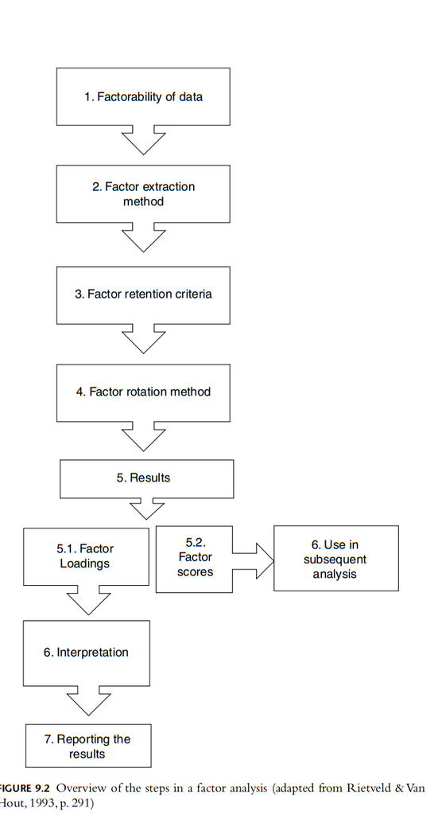

Rietveld & Van Hout (1993)

ここでは古典的な方法と洗練された方法をいくつか紹介いたします。

1. ガットマン基準
2. スクリープロットを見る
3. 累積寄与率をみる
4. 平行分析
5. MAP
6. VSS
7. 解釈可能性を考える

参考文献の小杉先生、分寺先生の講義資料、清水先生のブログ、清水(2018)、堀(2005)を参考にしています。

## 4.1 ガットマン基準

英語だとthe Kaiser criterion, the Kaise-Guttman rule, the eigenvalueone criterion, truncated principal components, the K1 rule と様々なものがある（Preacher & MacCallum,2003）。日本語でもいろいろな言い方がある。

因子分析では**データの**相関行列(正確には独自性を除いた $AA^T$ )を固有値分解することで因子負荷量行列を求めます。 したがって固有値が因子負荷の合計、共通性の合計を規定しています。

実は、 $I \times I$ の相関行列を固有値分解して得られる $I$ 個の固有値の**合計が必ず** $I$ **になる**という性質があります。つまり、固有値は $I$ 個の項目に対する共通性を再分配した値である。

イメージ的には例えば第一因子に対する固有値(の中の最大値)が4だとすると、その因子は1つで合計4項目分の分散を説明しているということです。

こう考えると固有値が1より小さい因子は1項目分の情報も持っていないということになります。 よって**「固有値が1以上の因子のみを使う」**という基準を**カイザー基準**と呼びます。

ガットマン基準がいまだに最も使われていると思われますが、その問題点も長らく指摘されているようです。

清水(2018)

```
相関行列の固有分解から得られる固有値を大きいものから順に1.0以上の値を示す個数を因子の数とするのがGuttman 基準あるいはKaiser-Guttman基準であった（Kaiser, 1960; Guttman, 1954）。(中略)方法の問題点は、対角項に共通性ではなく、1.0を置いた相関行列を対象としていることにある。
固有値の値を手がかりとするKaiser-Guttman基準やScreeは、このようにみてみると、因子ではなく主成分を対象としていることになる。
```

もしデータが**母相関行列**であるならこの方法は適切ですが、実際のデータには誤差(独自性の部分)が含まれるので「あてにならない」因子数を提案します。

堀(2005)より

```
...カイザー基準では因子数を多くも，少なくも，正しくも推測する。つまり，カイザー基準は大雑把であり，それほどあてにならないということである。
```

まとめると主成分を対象にしている分析なのに因子分析における因子数決定に用いているので適切な手法ではないということです。

## 4.2 スクリープロットを見る

**スクリープロット (screeplot)**とは、固有値を大きい順にならべ、横軸に大きさの順番、立て軸に固有値の値をとった折れ線グラフのことです。これを見て**大きな変化が見られたところを基準/ プロット的に傾きがなだらかになる手前の因子数を選択する**とし、因子の数を決める手法を**スクリーテスト(scree test)**といいます。

従来(Catell, 1966)におけるscree test ではカイザー基準同様**データの相関行列**の固有値分解から得られる固有値を大きい順に並べる(主成分を対象にする)ものでしたが、Rでは主成分(PC)及び因子分析(FA)両方のスクリープロットを出力してくださいます。参照をする際はFAの方のプロットを見ましょう。

### 4.2.1 Rでやってみる

第4回のpsychパッケージのbfiデータを用いてスクリープロットを出してみましょう。 スクリープロットは`scree()`で出力できます。

```r
library(psych)
library(GPArotation)
```

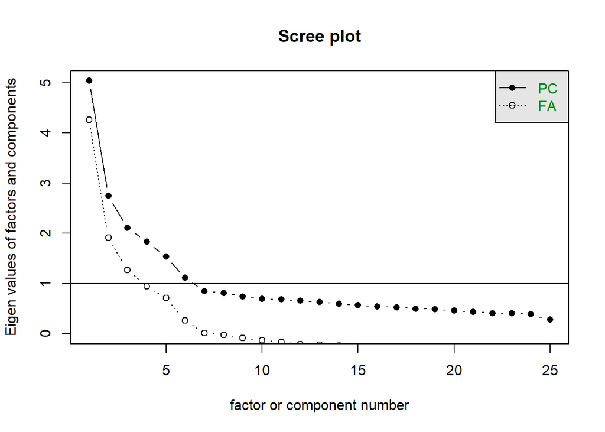

```r
#逆転項目の対処
gyakuten <- c(1, 9:12, 22, 25) #後から編集しやすいように逆転項目の列番号をベクトルにする
df <- bfi[1:25] #編集するデータを作る
df[, gyakuten] <- 7 - df[, gyakuten]

#スクリープロットを出す
scree(df)
```

ガットマン基準に相当するのが(PCのプロットで?)1以上の固有値を持つ因子数(6個)、 スクリーテストでは結果はFAの方をみましょう。ほとんどの場合PCの結果がFAのものより大きくなりますがその理由はFAとPCAの違いで再度触れます。

この場合だと第2か第6因子以降がなだらかになっているのでしょうか。 データ次第で**はっきりとした変化点を見いだせない**ケースがあるので、あまり客観的な指標として用いることはできないという指摘があります。

ちなみにpolychoric correlationでスクリープロットを書いてみる。 やはりはっきりとなだらかになっているところが分かりにくいです。

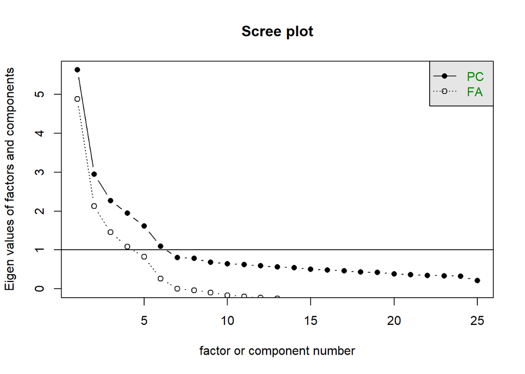

```r
cor_poly<- polychoric(df)
scree(cor_poly$rho)
```

## 4.3 累積寄与率をみる

小杉(2018)

```
固有値の大きさを項目数で割ることで、1つの因子が全体分散の何%を説明するかを算出できます。これをとくに寄与率 (contribution ratio) といいます。
これをどんどん積み重ねていって(累積)、累積寄与率(cumulative contribution ratio)が50%を超えるところまでを共通成分とみなす、という方法です。
因子分析は項目情報の圧縮をしていることでもあり，共通因子に入れないものはゴミとして捨てるようなものですが、全体の半分以上をゴミとして捨てたらいかんでしょ、という基準です。
```

ここでは「最低条件として」、累積寄与率が一定の値以上になっていない場合は因子の数を増やしてそれを満たすようにしよう、というようなアプローチをとっています。

### 4.3.1 Rでやってみる

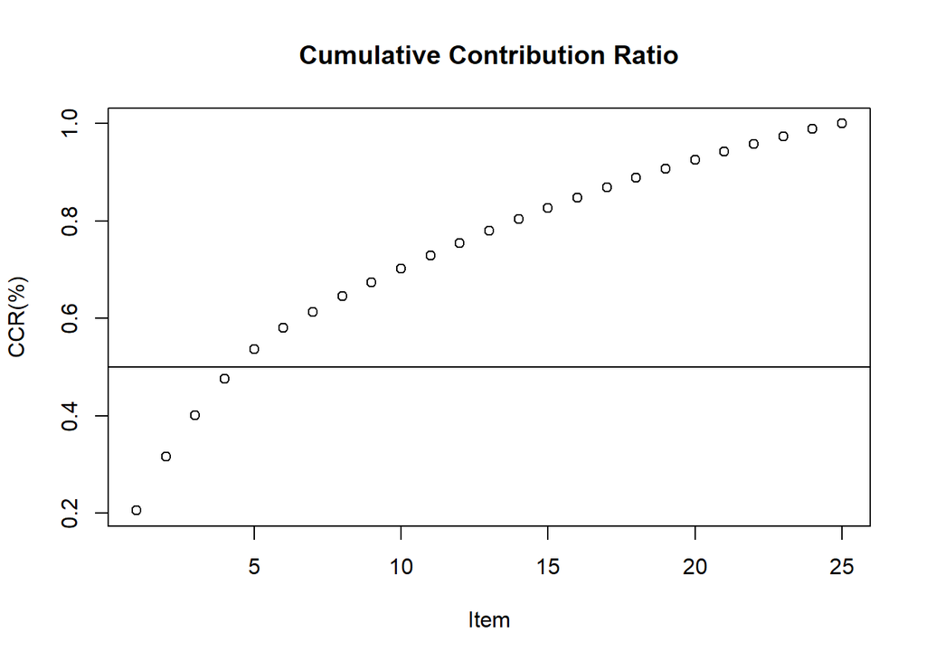

```r
cor_df <-cor(df, use="na.or.complete") #相関行列
c <- eigen(cor_df)$values/ ncol(df) #固有値/項目数
ccr <- cumsum(c)

plot(ccr, main= "Cumulative Contribution Ratio", ylab= "CCR(%)", xlab="Item")
abline(h=0.5)
```

この場合だと因子数は5因子になりますね。

## 4.4 平行分析

Screetestより洗練された方法です。ここでは個人的にわかりやすくて感動した分寺さんの授業資料の説明を参考にします。

**平行分析(parallel analysis)**ではデータからの固有値と「乱数での固有値」との比較を行います。

通常乱数のデータでは相関はないはずですが、標本誤差の完成などで相関が完全にゼロになることはありません。相関が完全にゼロではない限りは固有値分解を行うと第一固有値の値は1より少し大きくなります。

Rでたしかめてみましょう。

```r
#分析するデータセットと同じサイズの乱数を発生させる
df_rnd <- matrix(runif(ncol(df)*nrow(df)), ncol=ncol(df))
eigen(cor(df_rnd))$values
```

```
 [1] 1.1686010 1.1391091 1.1235193 1.1133492 1.0973587 1.0888547 1.0688672
 [8] 1.0473694 1.0396619 1.0243349 1.0080930 1.0043951 0.9905191 0.9886136
[15] 0.9807484 0.9656199 0.9464667 0.9402973 0.9328595 0.9274337 0.9066366
[22] 0.8998313 0.8799615 0.8688677 0.8486313
```

確かに第一固有値の値は1以上になりました。このデータにカイザー基準を当てはめると12因子もあることになってしまいます。

乱数に因子などないはずなので、**乱数で得られた固有値よりも小さい値は因子として無意味**と判断します。

### 4.4.1 Rでやってみる

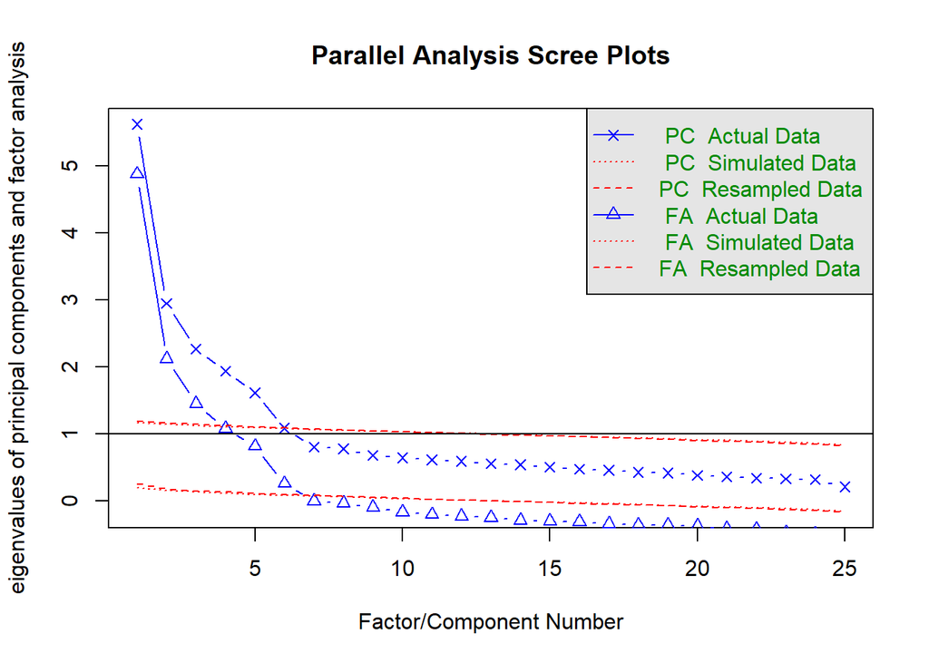

```
Parallel analysis suggests that the number of factors =  6  and the number of components =  5
```

```r
fa.parallel(df, cor = "poly") #引数cor
```

青い線が実データでの固有値、赤い線が乱数での固有値を表しています(乱数なので毎回少し結果が変わるかもしれませんが)。 今回もFAの結果を見ましょう。 コンソールの出力を見ると6因子が推奨されてます。

## 4.5 MAP

MAP(Minimum Average Partial; Velier MAP; 最小平均偏相関)では、データの相関行列のうち共通因子の影響を取り除いた偏相関の部分に着目します。

つまり、誤差どうしの相関で、これが全てゼロであれば独自因子の間に別の共通因子が存在していないことになるので、因子数として妥当だと判断できます。

行列表現は分寺先生の授業資料に記載されているので参照されたい。

## 4.6 VSS

因子分析では**単純構造**を目指して回転が行われます。VSS(Very Simple Structure)基準(Revelle & Rocklin, 1979)は得られた結果を強制的に単純構造にしたときのデータの整合性を見ます。 完全な単純構造では各項目1つの因子にのみ負荷をもっており、VSSでは最も高い負荷をもっている因子以外の負荷をゼロにした因子負荷行列を考えます。

その因子負荷行列( $\tilde A_{VSS}$ )に対して $\tilde A_{VSS} ^\intercal \Phi \tilde A_{VSS}$ によって相関行列を復元します。 データの相関行列 $\Sigma$と比較して、差が小さければ「単純構造とみなしたときにデータと整合性がある」ということになります。

### 4.6.1 Rでやってみる

Rのpsychパッケージで`VSS()`を使用します。MAPについてもこれで確認できます。

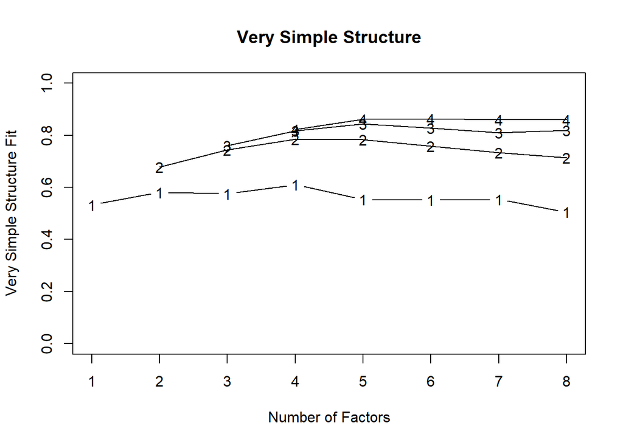

[output not shown]

```r
VSS(df, cor="poly")
```

VSSではほかにも以下のような指標を出力します。 - 情報量基準BICが最も小さくなる因子数 第4回で確認したように、8因子のときBICは最小になる。なお、値が異なるのはBICの計算の仕方がソフトやパッケージによって少々異なるからである(尤度に関する定数項の部分を入れるかどうかとかが違うらしい)。 比較する場合は同一関数で出力したBICから、一番小さいものを選びましょう。

- 共通因子の影響を取り除いた残差相関行列に対する χ$^2$ 統計量
- RMSEA, SRMRなどのモデルの適合度指標

## 4.7 解釈可能性を考える

以下分寺先生の資料より:

```
多くの基準を紹介してきましたが、これらの結果は一貫していません。

因子分析で重要なのでは**解釈可能性**であり、因子の名前は分析者の知識と経験をもとに項目の共通点をラベリングしなくてはいけません。(中略) 統計的に最適と思われる因子数が提案されても標本誤差の影響を受けている可能性がゼロとは言えません。

探索的因子数を決定する際には

1. `VSS()`や`fa.parallel()`によって因子数にアタリをつける

2. 提案された因子数に関して実際に因子分析を行う

3. 得られた結果をもとに因子の解釈を行う

4. 最もしっくりくる解釈が得られた因子数・因子構造を採用する

という手順で行われることが多いでしょう。もしも全ての統計的な基準がさしている因子数において解釈が難しいという事態に直面したら、そのときは泣いてください。
```

とのことです。第4回でも行ったように複数の因子数・構造を検討し、解釈可能性が一番高いものを選びましょう。

# 5 FAとPCAの違い

第4回でも説明しましたが、EFAとPCAの違いは一言でいうと独自因子を設定している(EFA)かいないか(PCA)です。

もう少し具体的に説明しましょう。因子分析では，観測変数の相関行列 𝚺 を $AA^⊤ + 𝚿$ と分解した上で，$AA^⊤$の部分に対して固有値分解を行うことで因子負荷量を計算していました。これに対して主成分分析では $𝚺$ そのものを固有値分解したものが主成分負荷量になります。主成分分析のほうが$𝚿$のぶんだけ大きな値の行列を固有値分解するため，得られる固有値も大きな値になります。

スクリープロットでPCAの値の方が大きくなる理由がこれにあたります。

# 6 因子間相関

因子を特定するうえで、因子負荷量とともに重要な役割を果たすのが因子間相関

e.g. 因子1と因子5の相関が0.3だったとき、それらの因子は弱い相関を持つといえるので、両者に全く無関係の概念が当てはまるということは無さそう

小塩, 2004, p. 29より

```
概ね、0～0.3未満：ほぼ無関係、0.3～0.5未満：非常に弱い相関、0.5～0.7未満：相関がある、0.7～0.9未満：強い相関、0.9以上：非常に強い相関
```

因子間相関をてがかりに因子の解釈をしましょう。

## 6.1 おまけ: 因子間相関のモデル化

研究のネクストステップとして先行研究で提案された因子構造が他の研究でも再現されるかどうかを検討するかもしれません。 それを行う場合**確認的因子分析**を実施するかもしれません。 確認的因子分析では各項目がどの因子に対応しているか、因子間の関係はどうなるかを考えて(モデル化して)、 データをモデルに当てはめる、という作業することになります。

せっかくbig fiveのお話をしたので因子間相関をモデル化する際に使うモデルを紹介します。

1. 因子間相関を仮定する場合

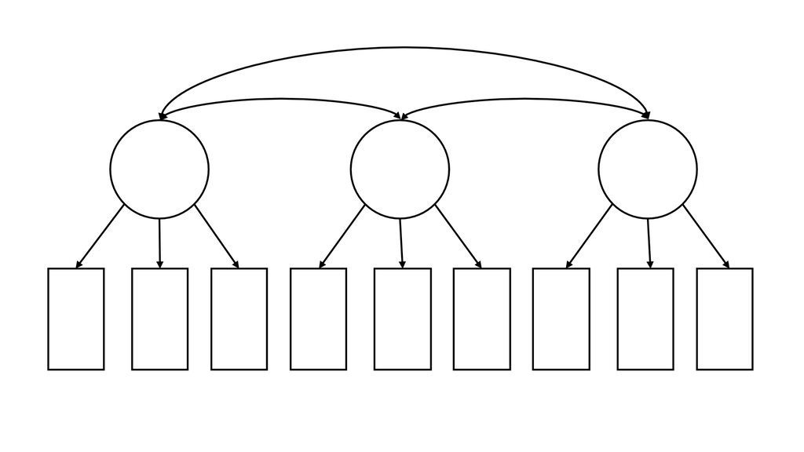

独自因子は省略します

2. 高次因子を仮定する場合

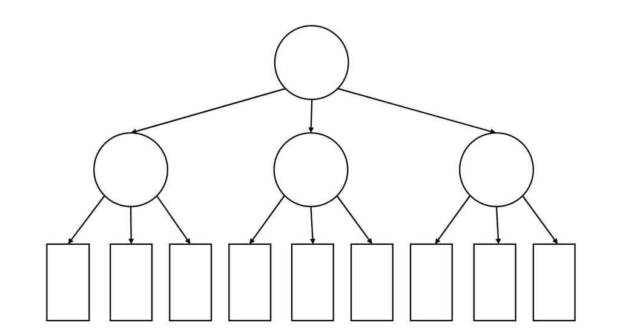

Second-order model

3. 別の共通因子を仮定する場合

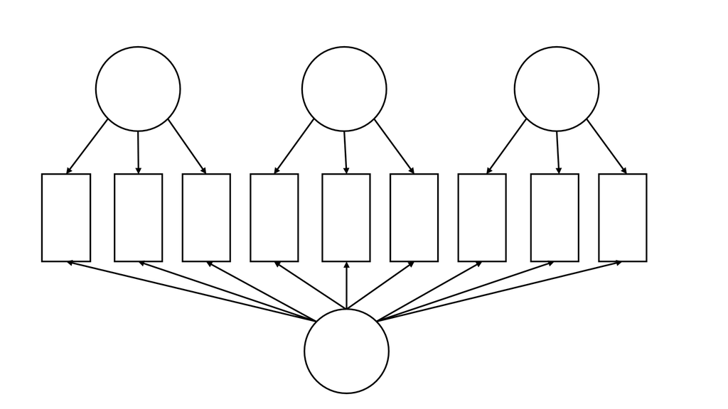

Bifactor model

# 7 Rの結果の読みかた

[分寺先生の資料](https://www2.kobe-u.ac.jp/~bunji/files/lecture/MVA/mva-06-factor-analysis.pdf)の第6.4節に各出力の意味するところが書かれています。

# 8 最終発表

今回は既存知識のないデータセットを解析し(実践に近いように)因子を特定する作業をしていただく。

データを5つ準備しています。Slackで希望の番号を教えてください。 被った場合は話し合いできめてください。

データは[Github](https://github.com/Higashiguchi-Rinhi/tokushujikken/tree/f77448026bab2861c625c1395a547ce0d709ceb3/dataset)にあります。

1. Website user experienceのflowに関する質問紙
2. Airline Passenger Satisfactionに関する質問紙
3. Firstborn Personality Scale
4. 性格特性に関する質問紙
5. Humor Styles Questionnaire

第6回の授業で各自5分質疑2分の短い発表を行ってもらいます。 Powerpointを使用するのでも、Rの結果を見せながら発表するのでなんでも大丈夫です。

含める内容は以下です。

1. データの説明(どんなデータなのか、項目数などの記述統計量)
2. 行った分析
3. その結果
4. 結果の解釈(因子のラベリング)

評価するのは①分析の手続きを過不足なく報告しているか(再現可能性)、②統計的基準に従って分析しているか(客観性)です。

本講義で触れなかったものはもちろん使用していただいて構いませんが、できれば学術論文、もしくは検索してわかる形での引用をしていただければと思います。

探索的因子分析を行った結果を発表する際、最終的な分析結果が出るまでの試行錯誤の過程の、どの部分をどの程度説明として含めるべきなのかが気になりました。

尺度開発の学術論文では(ページ数の関係上)あまり細かい分析は記載されていないですが、最終発表では因子数と因子の回転をいろいろ試すと思うのですが、それに関しては一番解釈が良かったものを発表していただく形で大丈夫です。

もちろん面白い結果や、迷った点など紹介したい場合があればご紹介いただいて構いません。

# 9 最終課題

来週もまた提示しますが、最終発表と同様以下の内容を文章で(A4のドキュメントになるように)pdfの形にまとめてください。もちろん、図とかを多用していただいて構いませんし、論文ほどフォーマットは厳しくなくていいです。

締め切りは【11/27(水), 23:59】です。 ファイル名は「出席番号_氏名_特殊実験.pdf」でお願いします。 提出はSlackのDMでお願いします。

内容は最終発表とその際の質疑やコメントを踏まえた分析に加え**5.も可能であれば**やってみてください。

1. データの説明(どんなデータなのか、項目数などの記述統計量)
2. 行った分析
3. その結果
4. 結果の解釈(因子のラベリング)
5. データセットに関する先行研究を調べ、ご自身の結果の解釈との相違点について考察

評価するのは①分析の手続きを過不足なく報告しているか(再現可能性)、②統計的基準に従って分析しているか(客観性)、に加え③先行研究や知見を踏まえた考察ができているかです。

③は明確に先行研究をもってくるのが難しい人がいると思いますが、因子のラベリングにおいて項目の意味を吟味しているか…とかもここに含まれます。

質問等あればご連絡ください。

# 10 参考文献

- 小杉 考司. 2019. 順序尺度の相関係数（ポリコリック相関係数）について–Kosugittiの研究ノート. https://kosugitti.github.io/kosugitti10/notes/polychoricNote.pdf
- 清水和秋. 2018.「因子分析的研究におけるmisuseとartifact」『関西大学社会学部紀要』,49(2), 191-211. https://ci.nii.ac.jp/naid/120006464566
- 清水裕士. (2012, July 31). カテゴリカルデータの相関係数 Sunny side up! Sunny Side Up!. https://norimune.net/673
- 清水裕士. (2012, May 23). 因子分析における因子数選択のための基準 Sunny side up! Sunny Side Up!. https://norimune.net/657
- 萩生田伸子・繁桝算男 (1996). 順序付きカテゴリカルデータへの因子分析の適用に関するいくつかの注意点 心理学研究，67(1), 1–8. https://doi.org/10.4992/jjpsy.67.1
- 分寺杏介. 2022. 神戸大学経営学研究科「統計的方法論特殊研究（多変量解析）」の講義資料「06_因子分析」: https://www.docswell.com/s/BunjiRo/K4QRRL-%E5%A4%9A%E5%A4%89%E9%87%8F%E8%A7%A3%E6%9E%90_06_%E5%9B%A0%E5%AD%90%E5%88%86%E6%9E%90#p41
- 堀啓造, 2005,「因子分析における因子数決定法 : 平行分析を中心にして」『香川大学經濟論叢』77(4), 545-580.1 https://ci.nii.ac.jp/naid/110004617144